# Lab 3

Jiajia Feng

2024-05-14

```r
library(astsa)
library(forecast)
```

## Problem 1

### (a)

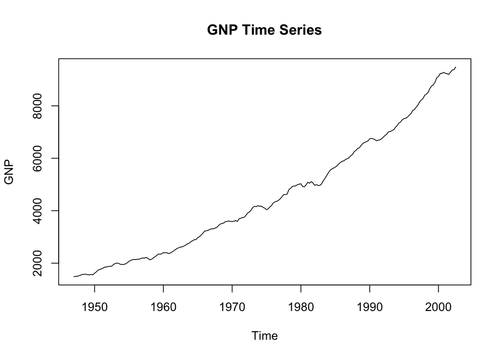

```r
plot(gnp, main="GNP Time Series", xlab="Time", ylab="GNP")
```

In this plot, the GNP is clearly increasing over time, indicating a trend in the data. The variance also appears to be increasing as the level of GNP rises, which is another sign of non-stationarity.

### (b)

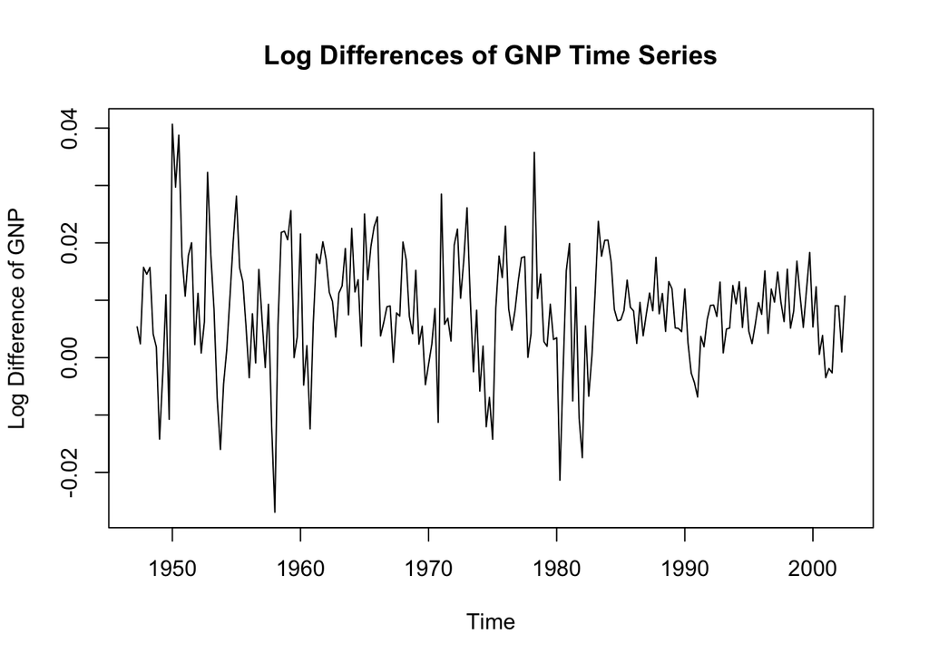

```r
log_diff_gnp <- diff(log(gnp))
plot(log_diff_gnp, main="Log Differences of GNP Time Series", xlab="Time", ylab="Log Difference of GNP")
```

### (c)

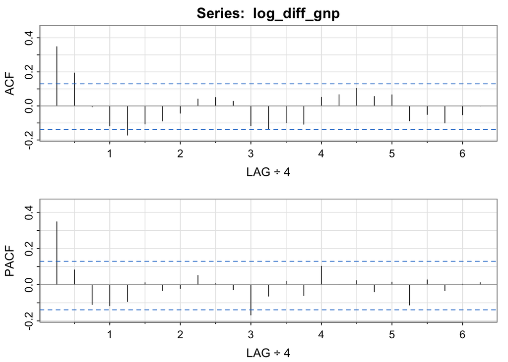

```
##      [,1] [,2]  [,3]  [,4]  [,5]  [,6]  [,7]  [,8] [,9] [,10] [,11] [,12] [,13]
## ACF  0.35 0.19 -0.01 -0.12 -0.17 -0.11 -0.09 -0.04 0.04  0.05  0.03 -0.12 -0.13
## PACF 0.35 0.08 -0.11 -0.12 -0.09  0.01 -0.03 -0.02 0.05  0.01 -0.03 -0.17 -0.06
##      [,14] [,15] [,16] [,17] [,18] [,19] [,20] [,21] [,22] [,23] [,24] [,25]
## ACF  -0.10 -0.11  0.05  0.07  0.10  0.06  0.07 -0.09 -0.05 -0.10 -0.05  0.00
## PACF  0.02 -0.06  0.10  0.00  0.02 -0.04  0.01 -0.11  0.03 -0.03  0.00  0.01
```

```r
library(astsa)
acf2(log_diff_gnp)
```

### (d)

```r
library(forecast)
ma.model <- Arima(log_diff_gnp, order=c(0,0,2))
summary(ma.model)
```

```
## Series: log_diff_gnp
## ARIMA(0,0,2) with non-zero mean
##
## Coefficients:
##          ma1     ma2    mean
##       0.3028  0.2035  0.0083
## s.e.  0.0654  0.0644  0.0010
##
## sigma^2 = 9.041e-05:  log likelihood = 719.96
## AIC=-1431.93   AICc=-1431.75   BIC=-1418.32
##
## Training set error measures:
##                        ME       RMSE         MAE  MPE MAPE      MASE       ACF1
## Training set 9.940243e-06 0.00944414 0.007108452 -Inf  Inf 0.6185504 0.01725908
```

### (e)

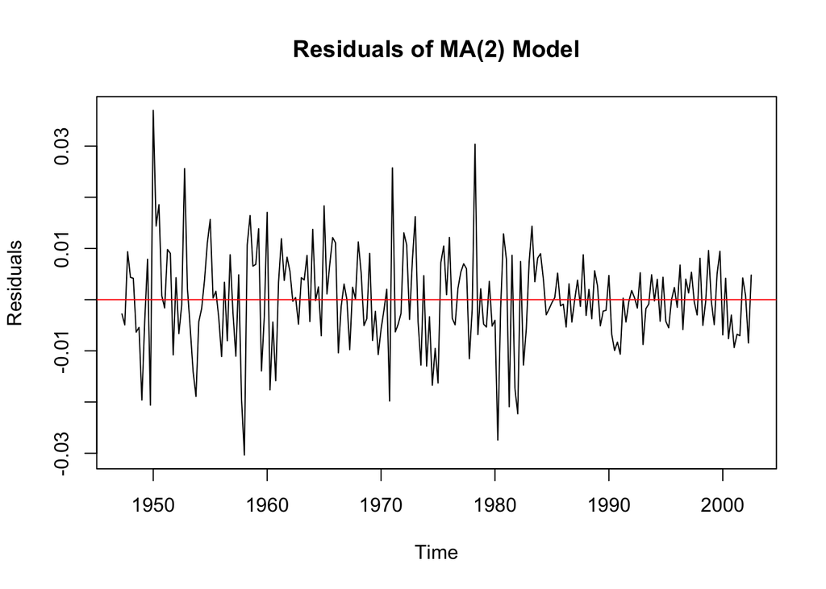

```r
residuals <- ma.model$residuals
plot(residuals, main="Residuals of MA(2) Model", ylab="Residuals", xlab="Time")
abline(h=0, col="red")
```

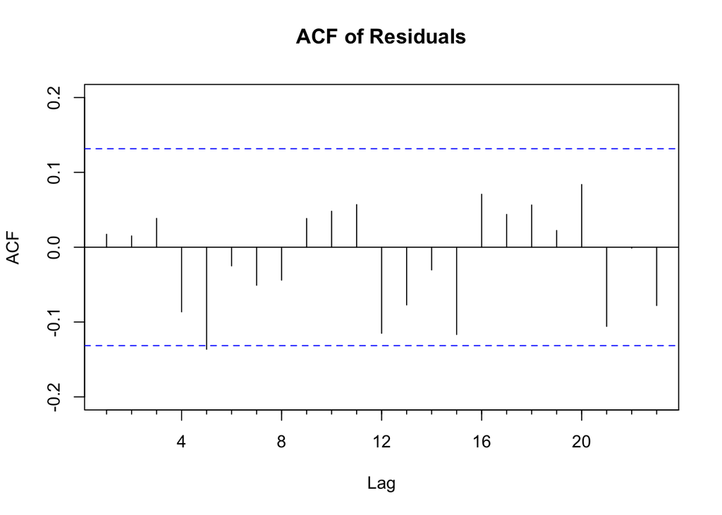

```r
Acf(residuals, main="ACF of Residuals")
```

The absence of patterns in the residuals and the lack of significant autocorrelation in the ACF plot collectively suggest that the MA(2) model is a good fit for the data.

### (f)

```r
ar.model <- Arima(log_diff_gnp, order=c(1,0,0)) # AR(1) model
summary(ar.model)
```

```
## Series: log_diff_gnp
## ARIMA(1,0,0) with non-zero mean
##
## Coefficients:
##          ar1    mean
##       0.3467  0.0083
## s.e.  0.0627  0.0010
##
## sigma^2 = 9.112e-05:  log likelihood = 718.61
## AIC=-1431.22   AICc=-1431.11   BIC=-1421.01
##
## Training set error measures:
##                        ME        RMSE        MAE  MPE MAPE      MASE
## Training set 5.572162e-06 0.009502405 0.00713417 -Inf  Inf 0.6207883
##                     ACF1
## Training set -0.02706632
```

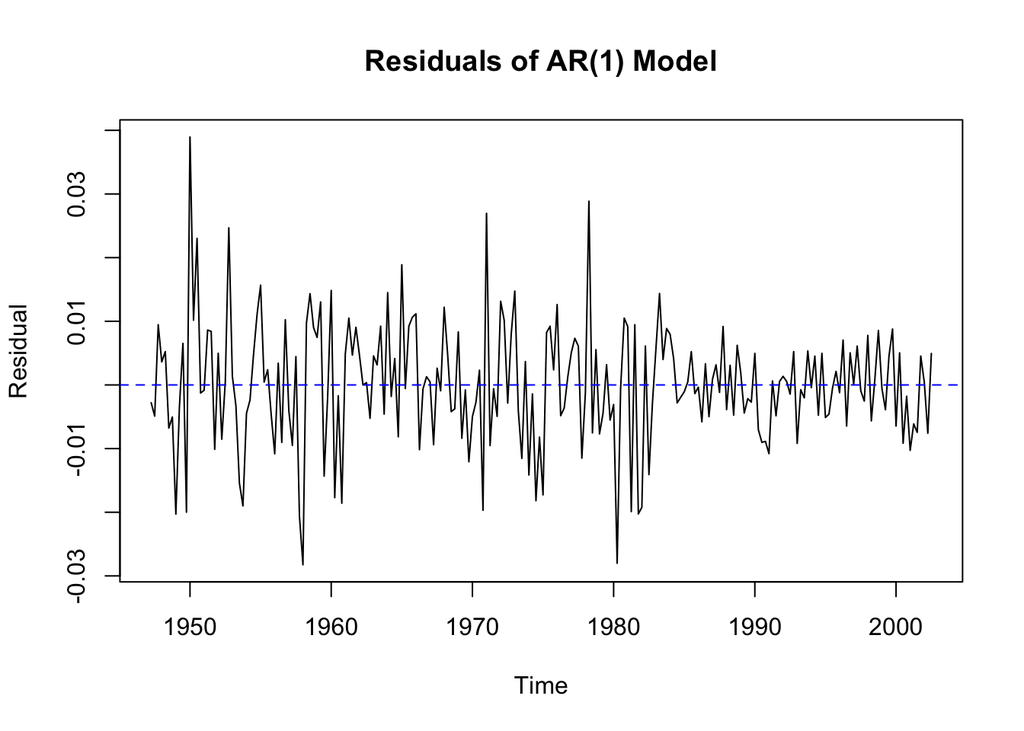

```r
plot(ar.model$residuals, main="Residuals of AR(1) Model", ylab="Residual", xlab="Time")
abline(h=0, col="blue", lty=2)
```

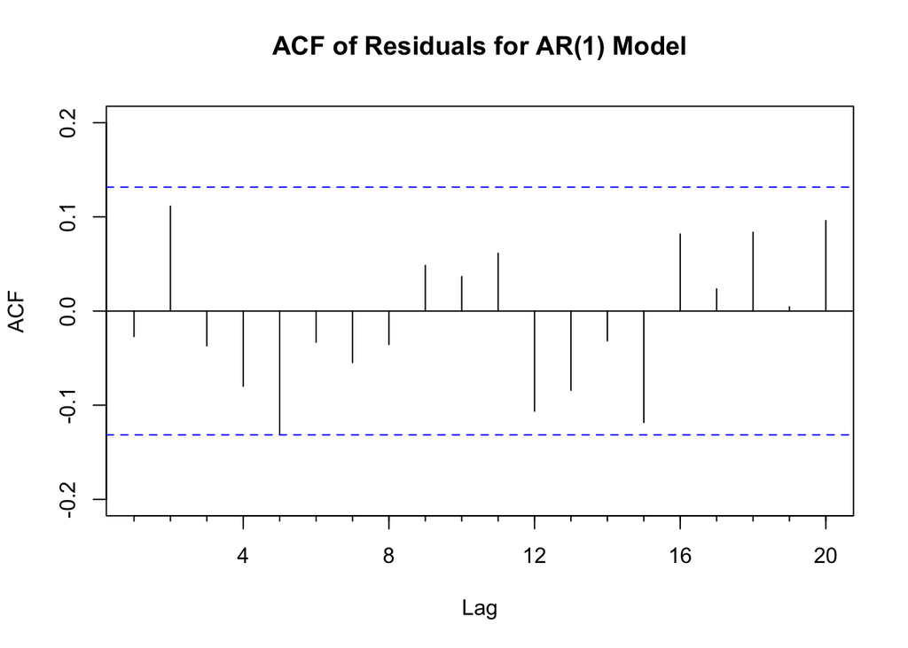

```r
Acf(ar.model$residuals, main="ACF of Residuals for AR(1) Model", lag.max=20)
```

### (g)

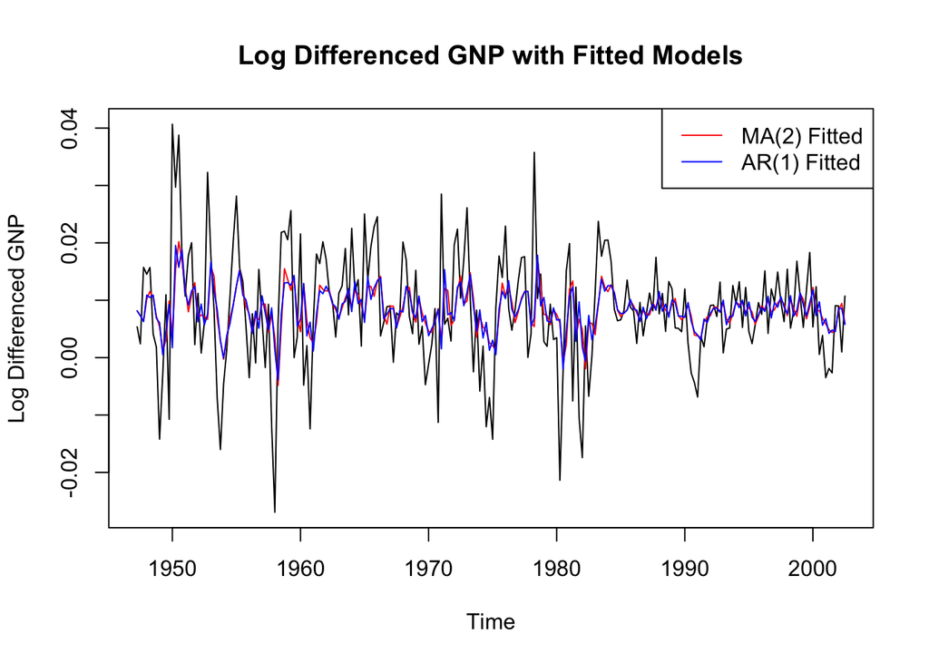

```r
plot(log_diff_gnp, main="Log Differenced GNP with Fitted Models",
     ylab="Log Differenced GNP", xlab="Time")
lines(ma.model$fitted, col="red")
lines(ar.model$fitted, col="blue")
legend("topright", legend=c("MA(2) Fitted", "AR(1) Fitted"), col=c("red", "blue"), lty=1)
```

## Problem2

### (a)

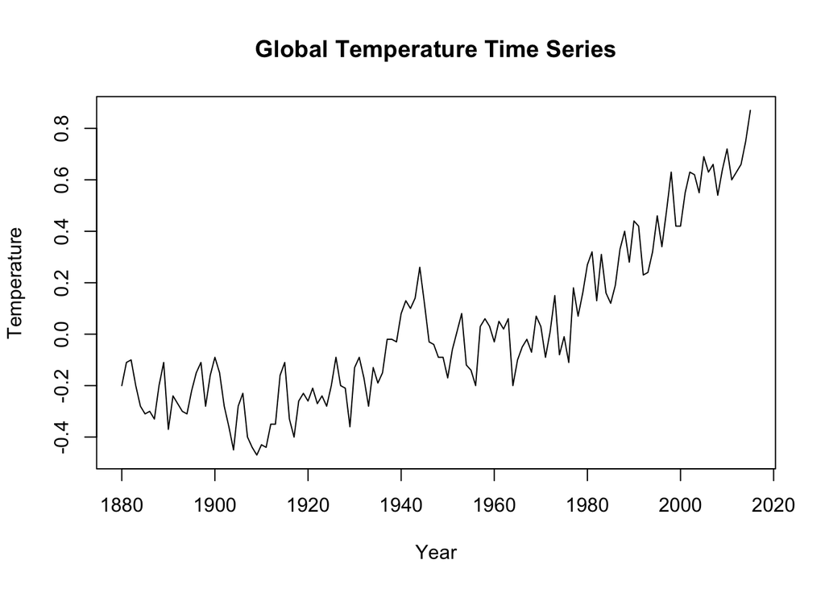

```r
library(astsa)
data(xglobtemp)
plot(xglobtemp, main="Global Temperature Time Series", xlab="Year", ylab="Temperature")
```

The data does not appear to be stationary due to the following reasons:

Trend: There is a clear upward trend over time. The temperature is increasing, which indicates that the mean of the series is not constant.

Variance: The increasing trend might suggest that the variance could be changing as well, particularly if the rate of increase is not constant.”

Seasonal Trend: The plot does not immediately suggest a strong seasonal component; the fluctuations appear irregular rather than systematic throughout the series.

Removing Seasonal Trend: If there’s an underlying seasonal trend not visible in the current plot, apply seasonal differencing, which involves subtracting the observation from the same season in the previous cycle.